# Solutions Exercise 2 - MRP

Inventory Management

Thomas Kirschstein

# Net demand calculation

1. Display the production process in modular lists and derive the direct production coefficient matrix $A$.

```r
A <- matrix(0, ncol=7, nrow=7)
colnames(A) <- rownames(A) <- c("A","B","II","I","a","b","c")
A[,"A"] <- c(0,0,4,0,5,0,0)
A[,"B"] <- c(0,0,2,7,0,4,4)
A[,"II"]<- c(0,0,0,4,2,3,0)
A[,"I"] <- c(0,0,0,0,0,2,1)
A
##    A B II I a b c
## A  0 0  0 0 0 0 0
## B  0 0  0 0 0 0 0
## II 4 2  0 0 0 0 0
## I  0 7  4 0 0 0 0
## a  5 0  2 0 0 0 0
## b  0 4  3 2 0 0 0
## c  0 4  0 1 0 0 0
```

2. Determine the gross demand matrix $G$.

```r
G <- round(solve(diag(1, 7) - A))
G
##     A  B II I a b c
## A   1  0  0 0 0 0 0
## B   0  1  0 0 0 0 0
## II  4  2  1 0 0 0 0
## I  16 15  4 1 0 0 0
## a  13  4  2 0 1 0 0
## b  44 40 11 2 0 1 0
## c  16 19  4 1 0 0 1
```

3. Calculate the net demand for all products, parts, and materials.

```
##    [,1]
## A    70
## B    78
## II  441
## I  2320
## a  1207
## b  6238
## c  2587
```

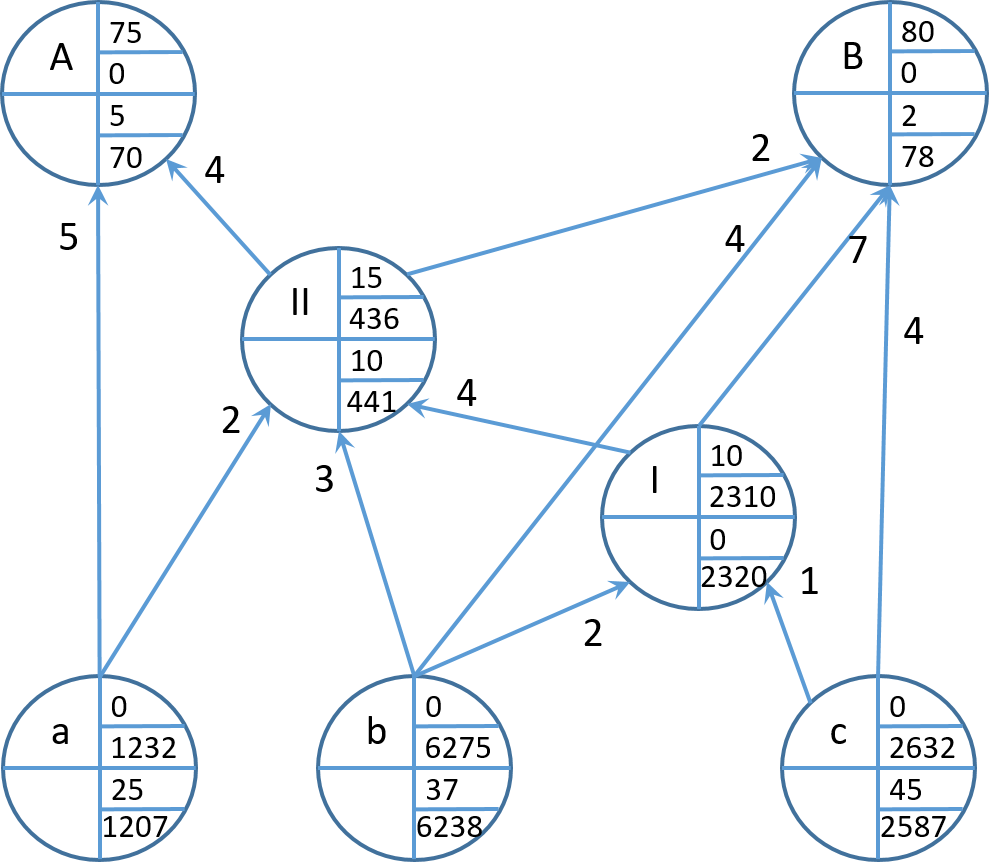

Gozinto graph

# Multi-period net demand calculation

1. Display the production process in a tree graph and determine the production stages of each component.

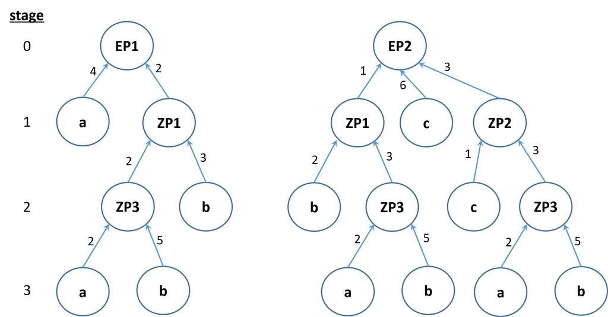

Tree graph

2. Calculate the net demands over time for all components.

```
## [[1]]
##            [,1] [,2] [,3] [,4] [,5] [,6] [,7] [,8] [,9] [,10]
## EP1-extDem    0    0    0    0    0    5    0    7    0    10
## EP1-intDem    0    0    0    0    0    0    0    0    0     0
## EP1-groDem    0    0    0    0    0    5    0    7    0    10
## EP1-stocks   15   15   15   15   15   15   10   10    3     3
## EP1-netDem    0    0    0    0    0    0    0    0    0     7
## EP1-iniDem    0    0    0    0    0    0    0    0    0     7
##
## [[2]]
##            [,1] [,2] [,3] [,4] [,5] [,6] [,7] [,8] [,9] [,10]
## EP2-extDem    0    0    0    0    0    0   15    0   20     0
## EP2-intDem    0    0    0    0    0    0    0    0    0     0
## EP2-groDem    0    0    0    0    0    0   15    0   20     0
## EP2-stocks   25   25   25   25   25   25   25   10   10     0
## EP2-netDem    0    0    0    0    0    0    0    0   10     0
## EP2-iniDem    0    0    0    0    0    0    0   10    0     0
##
## [[3]]
##            [,1] [,2] [,3] [,4] [,5] [,6] [,7] [,8] [,9] [,10]
## ZP1-extDem    0    0    0    0    0    5    0    0    0     0
## ZP1-intDem    0    0    0    0    0    0    0   10    0    14
## ZP1-groDem    0    0    0    0    0    5    0   10    0    14
## ZP1-stocks   20   20   20   20   20   20   15   15    5     5
## ZP1-netDem    0    0    0    0    0    0    0    0    0     9
## ZP1-iniDem    0    0    0    0    0    0    0    0    9     0
##
## [[4]]
##            [,1] [,2] [,3] [,4] [,5] [,6] [,7] [,8] [,9] [,10]
## ZP2-extDem    0    0    0    0    0   10    0    0    0     0
## ZP2-intDem    0    0    0    0    0    0    0   30    0     0
## ZP2-groDem    0    0    0    0    0   10    0   30    0     0
## ZP2-stocks   50   50   50   50   50   50   40   40   10    10
## ZP2-netDem    0    0    0    0    0    0    0    0    0     0
## ZP2-iniDem    0    0    0    0    0    0    0    0    0     0
##
## [[5]]
##            [,1] [,2] [,3] [,4] [,5] [,6] [,7] [,8] [,9] [,10]
## ZP3-extDem    0    0    0    0    0    5    0    0    0     0
## ZP3-intDem    0    0    0    0    0    0    0    0   18     0
```

[output cut: 16 more lines]

```
## b-extDem    0    0    0    0    0    0    0    0    0     0
## b-intDem    0    0    0    0    0    0    0    0   27     0
## b-groDem    0    0    0    0    0    0    0    0   27     0
## b-stocks   50   50   50   50   50   50   50   50   50    23
## b-netDem    0    0    0    0    0    0    0    0    0     0
## b-iniDem    0    0    0    0    0    0    0    0    0     0
##
## [[8]]
##          [,1] [,2] [,3] [,4] [,5] [,6] [,7] [,8] [,9] [,10]
## c-extDem    0    0    0    0    0    0    0    0    0     0
## c-intDem    0    0    0    0    0    0    0   60    0     0
## c-groDem    0    0    0    0    0    0    0   60    0     0
## c-stocks  100  100  100  100  100  100  100  100   40    40
## c-netDem    0    0    0    0    0    0    0    0    0     0
## c-iniDem    0    0    0    0    0    0    0    0    0     0
```

3. Assume the stock levels of materials a and b should be 250 at beginning of next week. When should the orders be placed?

4. Assume that material provision plan derived in 2. is to be evaluated on the basis of total logistics cost. Which types of cost should be considered and how could the plan be adapted in order to save costs?

Types of cost:

- stock-holding cost
- ordering/setup cost
- (obsolence cost)
- (backorder cost)

Total cost can be reduced potentially by consolidating future demand in joint lots. Thereby, setup costs can be reduced at the expense of stock-holding cost $\Rightarrow$ dynamic lot-sizing problem